# HW3

Zihan Lin

2023-11-03

```r
library(tcpl)
```

### Problem 1: Given the 4-dimensional multivariate normal distribution with mean vector

$$\mu^T = \begin{pmatrix}2
&1.5&3&1 \end{pmatrix}$$
and covariance matrix
$$\Sigma =
\begin{pmatrix}2.8&0&0.2&2\\0&1.7&2&0\\0.2&2&3.6&-1.2\\2&0&-1.2&3\end{pmatrix}$$
(a) Generate 1000 random observations from this multivariate normal distribution using the Choleski factorization method.

```r
mu <- c(2,1.5,3,1)
covmat <- matrix(c(2.8,0,0.2,2,0,1.7,2,0,0.2,2,3.6,-1.2,2,0,-1.2,3), nrow = 4)
x <- matrix(rnorm(4000),ncol = 4)
sample <- matrix(numeric(4000), nrow = 1000)
for(i in 1:1000){
  sample[i,] <- mu+(x%*%chol(covmat))[i,]
}
```

2. Draw an array of scatter plots for each pair of variables and examine if they agree with the parameters. (You may use pairs in R)

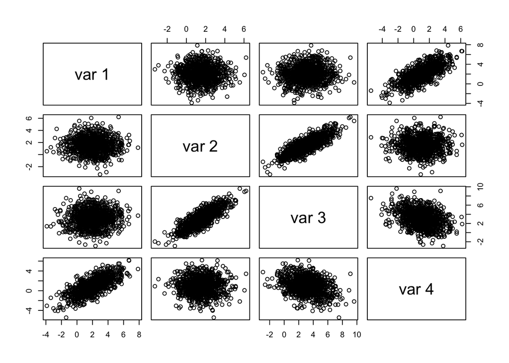

```r
pairs(sample)
```

Base on the pairs plot, I can tell that all means are around the $\mu$ vector that was given, and similar $\Sigma$ that was given.

### Problem 2: Write R code to standardize an d-dimensional multivariate normal sample X with the known $\Sigma$ and sample size n, where d and n can be arbitrary integer numbers.

1. Derive an algorithm for standardizing a multivariate normal sample.

To make the multivariate normal sample become standardized, we will make each sample subtract by their mean and divide by the standard deviation:
$$x_{standarized} = \frac{x -
\mu}{\sigma}$$
Or in this example we have d-dimensional multivariate normal X with size n

$$X_{standarized} =
(X-\mu)\Sigma^{-\frac{1}{2}}$$

2. Implement your algorithm in R.

```r
standarize <- function(X, mu, covmat){

  df <- matrix(numeric(length(X)), nrow = nrow(X))
  for(i in 1:nrow(X)){
    df[i,] <- X[i,]-mu
  }

  eigen_value <- eigen(covmat)
  covmat_inverse <- eigen_value$vectors %*% diag(1/sqrt(eigen_value$values)) %*% t(eigen_value$vectors)

  return(df %*% covmat_inverse)
}
```

3. Use the generated data from Problem 1 to verify your algorithm.

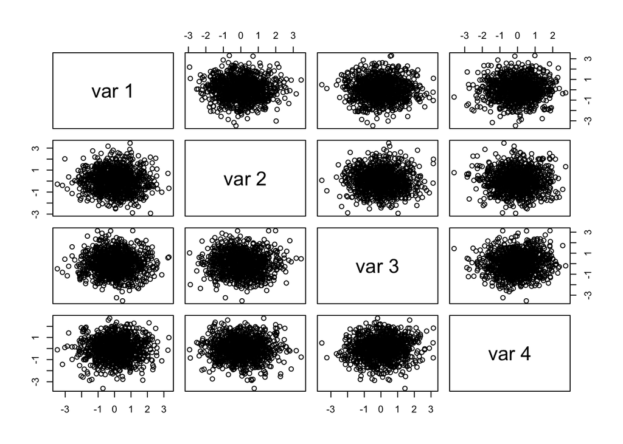

```r
df <- standarize(sample, mu,covmat)
pairs(df)
```

### Given X is a continuous random variable from the density f(x). Let $\theta = \int g(x)f(x)dx = E[g(x)]$. Suppose we draw iid samples $X_1,...,X_m$ from $f(x)$. Let $\hat \theta = \frac{1}{m}\Sigma_{i=1}^mg(X_i)$.

1. Prove $E[\hat \theta] =\theta$

$$E[\hat \theta] =
E[\frac{1}{m}\Sigma_{i=1}^mg(X_i)] =
\frac{1}{m}E[\Sigma_{i=1}^mg(X_i)]$$
$$E[\hat\theta] = \frac{1}{m}\Sigma_{i=1}^m\theta =
\frac{m\theta}{m} = \theta$$

2. Prove $Var[\hat \theta] = Var[g(X)]/m$, and specify how to estimate $Var[g(x)]$

$$Var[\hat \theta] =
Var[\frac{1}{m}\Sigma_{i=1}^mg(X_i)] =
\frac{1}{m^2}Var[\Sigma_{i=1}^mg(X_i)]$$
$$Var[\hat \theta] =
\frac{1}{m^2}(Var[g(X_1)]+...Var[g(X_m)]) = \frac{1}{m^2}mVar[g(X)] =
\frac{Var[g(X)]}{m}$$

3. Specify how to construct 99% confidence interval of $\theta$ using central limit theorem.

4. Suppose $f(x)$ is the exponential density with the rate, 1/3. Write a function (`mc2()`) to calculate a Monte Carlo estimate of $E[\sqrt{X}]$

```r
mc2 <- function(m){

  lambda <- 1/3
  return(mean(sqrt(rexp(m,lambda))))

}
```

$$\lambda = \frac{1}{3};\mu =
3;sd=\sqrt{9}=3;SE =
\frac{3}{\sqrt{m}}=\frac{3}{\sqrt{1000}}$$

```r
CI <- c(sqrt(3)+1.96*(3/sqrt(1000)), sqrt(3)-1.96*(3/sqrt(1000)))
mc2_samples <- numeric(1000)
for (i in 1:1000) {
 mc2_samples[i] <- mc2(1000)
}

result <- logical(1000)
for (i in 1:1000) {
  if(mc2_samples[i]>CI[2]){
    result <- c(result,FALSE)
  }else if(mc2_samples[i]<CI[1]){
    result <- c(result,FALSE)
  }
}

mc2_samples
```

[output not shown]

[output cut: 110 more lines]

```r
CI
```

```
## [1] 1.917993 1.546109
```